# Day 19 Activity: Clustering Colleges - SOLUTIONS

Instructor

ECON 122

## Introduction

In this activity, you’ll use K-means clustering to group colleges based on their characteristics. Unlike supervised learning where we have labeled outcomes, clustering is an **unsupervised learning** method that finds natural groupings in data.

**Learning Goals:**

- Apply K-means clustering to real data
- Determine the optimal number of clusters
- Interpret and visualize cluster assignments
- Understand the importance of standardizing variables

**Time:** Approximately 40 minutes

## Setup

Load the necessary packages:

```r
library(dplyr)
library(ggplot2)
library(readr)
library(tidyr)
```

## Part 1: Load and Explore the Data (5 minutes)

We’ll use college data from a CSV file with various institutional characteristics and create several derived variables:

```r
# Load the college data from CSV
colleges <- read_csv("https://raw.githubusercontent.com/mgelman/data/master/Colleges.csv")

# Create derived variables and select variables of interest
college_data <- colleges %>%
  mutate(
    avg_sat = (SATM + SATV) / 2,           # Average SAT score
    adm_rate = AppsAccept / AppsReceive,   # Admission rate
    cost = Tuition + RoomBoard + Books      # Total cost
  ) %>%
  # Select our variables of interest
  select(College, State,
         avg_sat,        # Average SAT score
         adm_rate,       # Admission rate
         HStop10,        # % of students from top 10% of HS class
         cost,           # Total cost
         Ratio,          # Student/faculty ratio
         Donate,         # % of alumni who donate
         AvgSalary,      # Average alumni salary
         FullTime        # Number of full-time students
  ) %>%
  # Remove rows with missing data
  filter(complete.cases(.))

# How many colleges remain after removing missing data?
nrow(college_data)
```

```
## [1] 401
```

**Q1: Calculate summary statistics (mean, median, min, max, standard deviation) for the key numeric variables across all colleges. What do you notice about the typical values and variability?**

```r
# Using summary()
summary(college_data %>% select(adm_rate, avg_sat, HStop10, cost, Ratio, Donate, AvgSalary, FullTime))
```

```
##     adm_rate         avg_sat         HStop10           cost
##  Min.   :0.1545   Min.   :300.0   Min.   : 1.00   Min.   : 3120
##  1st Qu.:0.6472   1st Qu.:460.5   1st Qu.:16.00   1st Qu.: 9078
##  Median :0.7689   Median :498.5   Median :25.00   Median :15610
##  Mean   :0.7279   Mean   :502.3   Mean   :29.28   Mean   :14903
##  3rd Qu.:0.8353   3rd Qu.:535.0   3rd Qu.:36.00   3rd Qu.:19075
##  Max.   :1.0000   Max.   :705.0   Max.   :98.00   Max.   :26800
##      Ratio           Donate        AvgSalary        FullTime
##  Min.   : 2.50   Min.   : 0.00   Min.   :232.0   Min.   :  139
##  1st Qu.:11.50   1st Qu.:14.00   1st Qu.:365.0   1st Qu.: 1047
##  Median :13.50   Median :22.00   Median :423.0   Median : 1739
##  Mean   :13.95   Mean   :23.67   Mean   :440.1   Mean   : 3720
##  3rd Qu.:16.10   3rd Qu.:32.00   3rd Qu.:506.0   3rd Qu.: 4123
##  Max.   :28.80   Max.   :63.00   Max.   :866.0   Max.   :31643
```

**Your answer:**

**Q2: Filter the data to include only Claremont Colleges (Pomona College, Claremont McKenna College, Harvey Mudd College, Scripps College, and Pitzer College). Calculate the same summary statistics for just these schools. Are these values what you would expect for the Claremont Colleges? How do they compare to the overall distribution? Based on these characteristics, what other types of schools do you think the Claremont Colleges would get clustered with?**

```r
# Your code here
# Hint: Use filter() with %in% to select multiple college names
claremont_colleges <- college_data %>%
  filter(College %in% c("Pomona College", "Claremont McKenna College",
                     "Harvey Mudd College", "Scripps College", "Pitzer College"))

# Display the Claremont data
claremont_colleges
```

```
## # A tibble: 5 × 10
##   College   State avg_sat adm_rate HStop10  cost Ratio Donate AvgSalary FullTime
##   <chr>     <chr>   <dbl>    <dbl>   <dbl> <dbl> <dbl>  <dbl>     <dbl>    <dbl>
## 1 Claremon… CA        635    0.412      71 23510   9.6     52       601      887
## 2 Harvey M… CA        685    0.415      95 24620   8.2     46       638      654
## 3 Pitzer C… CA        575    0.556      37 24238  10.4     11       547      750
## 4 Pomona C… CA        670    0.372      80 25740   8.9     47       566     1500
## 5 Scripps … CA        575    0.739      60 25188   8.2     41       511      569
```

```r
# Summary statistics for Claremont Colleges
summary(claremont_colleges %>% select(adm_rate, avg_sat, HStop10, cost, Ratio, Donate, AvgSalary, FullTime))
```

```
##     adm_rate         avg_sat       HStop10          cost           Ratio
##  Min.   :0.3721   Min.   :575   Min.   :37.0   Min.   :23510   Min.   : 8.20
##  1st Qu.:0.4124   1st Qu.:575   1st Qu.:60.0   1st Qu.:24238   1st Qu.: 8.20
##  Median :0.4154   Median :635   Median :71.0   Median :24620   Median : 8.90
##  Mean   :0.4990   Mean   :628   Mean   :68.6   Mean   :24659   Mean   : 9.06
##  3rd Qu.:0.5560   3rd Qu.:670   3rd Qu.:80.0   3rd Qu.:25188   3rd Qu.: 9.60
##  Max.   :0.7392   Max.   :685   Max.   :95.0   Max.   :25740   Max.   :10.40
##      Donate       AvgSalary        FullTime
##  Min.   :11.0   Min.   :511.0   Min.   : 569
##  1st Qu.:41.0   1st Qu.:547.0   1st Qu.: 654
##  Median :46.0   Median :566.0   Median : 750
##  Mean   :39.4   Mean   :572.6   Mean   : 872
##  3rd Qu.:47.0   3rd Qu.:601.0   3rd Qu.: 887
##  Max.   :52.0   Max.   :638.0   Max.   :1500
```

**Your answer:**

Based on these characteristics, the Claremont Colleges should cluster with other highly selective, private, small liberal arts colleges such as Williams, Amherst, Swarthmore, Carleton, Bowdoin, and similar elite small colleges - schools with low admission rates, high SAT scores, strong academic profiles, high costs, and small enrollments.

## Part 2: Your First K-means Clustering (10 minutes)

For clustering, we only need the numeric variables (not school names or state):

```r
# Create a dataset with only the clustering variables
cluster_vars <- college_data %>%
  select(adm_rate, avg_sat, HStop10, cost, Ratio, Donate, AvgSalary, FullTime)
```

**Q3: Use the `kmeans()` function to cluster the data (`cluster_vars`) into K=3 clusters. Use `nstart=20` and set a seed for reproducibility.**

```r
set.seed(122)
# Your code here
km_3 <- kmeans(cluster_vars, centers = 3, nstart = 20)
```

**Q4: Add these cluster assignments to your `college_data` dataframe as a new column called `cluster_3`.**

```r
# Your code here
college_data <- college_data %>%
  mutate(cluster_3 = km_3$cluster)
```

**Q5: Create a scatter plot of SAT scores vs. admission rates, colored by your cluster assignments. Do the clusters make sense based on these two variables?**

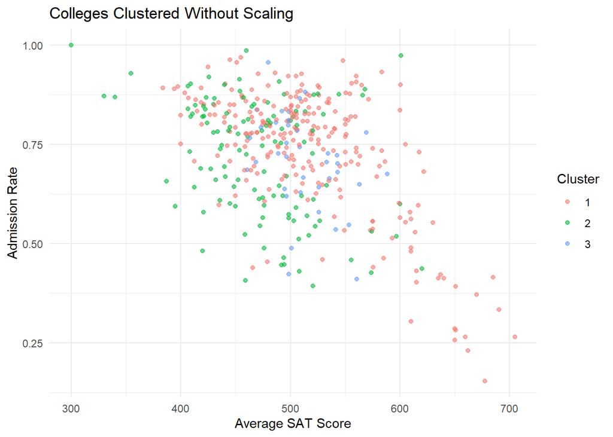

```r
# Your code here
ggplot(college_data, aes(x = avg_sat, y = adm_rate, color = factor(cluster_3))) +
  geom_point(alpha = 0.6) +
  labs(title = "Colleges Clustered Without Scaling",
       x = "Average SAT Score",
       y = "Admission Rate",
       color = "Cluster") +
  theme_minimal()
```

**Your answer:**

## Part 3: Now Try Clustering WITH Scaling (10 minutes)

Before we re-run the clustering, let’s think about what might have gone wrong.

**Q6: Look back at the summary statistics for `cluster_vars` from Part 2. Which variables have very different scales (i.e., much larger or smaller ranges of values)? Given what you observed in Q5, why do you think these scale differences might have caused problems for the clustering algorithm?**

**Your answer:**

**Q7: Create a standardized version of the clustering variables using the `scale()` function. Save it as `cluster_vars_scaled`.**

```r
# Your code here
cluster_vars_scaled <- scale(cluster_vars)

# You can check that it worked by looking at the means (should be ~0) and SDs (should be 1)
# colMeans(cluster_vars_scaled)
# apply(cluster_vars_scaled, 2, sd)
```

**Q8: Now use the `kmeans()` function to cluster the SCALED data into K=3 clusters. Use `nstart=20` and set the same seed.**

```r
set.seed(122)
# Your code here
km_3_scaled <- kmeans(cluster_vars_scaled, centers = 3, nstart = 20)
```

**Q9: Add the scaled cluster assignments to your original `college_data` dataframe as a new column called `cluster_scaled`.**

```r
# Your code here
college_data <- college_data %>%
  mutate(cluster_scaled = km_3_scaled$cluster)
```

**Q10: Create the same scatter plot (SAT scores vs. admission rates), but now colored by your cluster assignments from the SCALED data. Also add labels for the Claremont Colleges to see which cluster they ended up in. Do these clusters make more sense than your results from Q5? Were the Claremont Colleges clustered with the types of schools you predicted in Q2?**

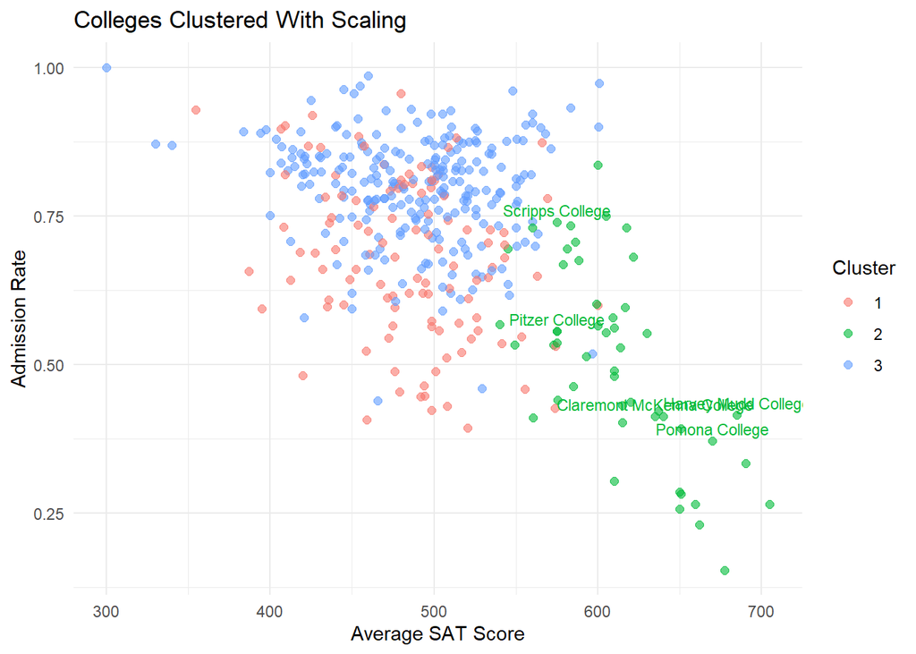

```r
# Your code here
# Hint: You can use geom_text() or geom_label() to add labels for Claremont colleges
# You might want to filter for just those schools or use ifelse() to create labels

# Create a label column (only label Claremont Colleges)
college_data <- college_data %>%
  mutate(claremont_label = ifelse(College %in% c("Pomona College", "Claremont McKenna College",
                                               "Harvey Mudd College", "Scripps College", "Pitzer College"),
                                   College, ""))

# Use geom_text for labels
ggplot(college_data, aes(x = avg_sat, y = adm_rate, color = factor(cluster_scaled))) +
  geom_point(alpha = 0.6, size = 2) +
  geom_text(aes(label = claremont_label),
                  size = 3,
                  vjust = -0.5,
                  show.legend = FALSE) +
  labs(title = "Colleges Clustered With Scaling",
       x = "Average SAT Score",
       y = "Admission Rate",
       color = "Cluster") +
  theme_minimal()
```

**Your answer:**

The clusters make MORE sense than before, but there’s still something odd. We can now see some separation based on selectivity (high SAT + low admission rate), but one of the clusters still doesn’t seem to make sense - it appears to group together colleges that don’t have similar selectivity profiles. The Claremont Colleges are grouped together, which is good, but their cluster also contains some schools that seem like they shouldn’t be there based on SAT scores and admission rates alone. Something is still influencing the clustering beyond just these two selectivity measures.

**Q11: Looking at Q10, you should notice that even with scaling, the clusters capture multiple dimensions. Why do you think this is happening? Create a scatter plot of admission rate vs. cost, colored by your scaled cluster assignments. Does this help explain the patterns in the clusters? After creating the plot, categorize each of the 3 clusters based on what you observe (e.g., “low-cost selective schools”, “high-cost selective schools”, etc.).**

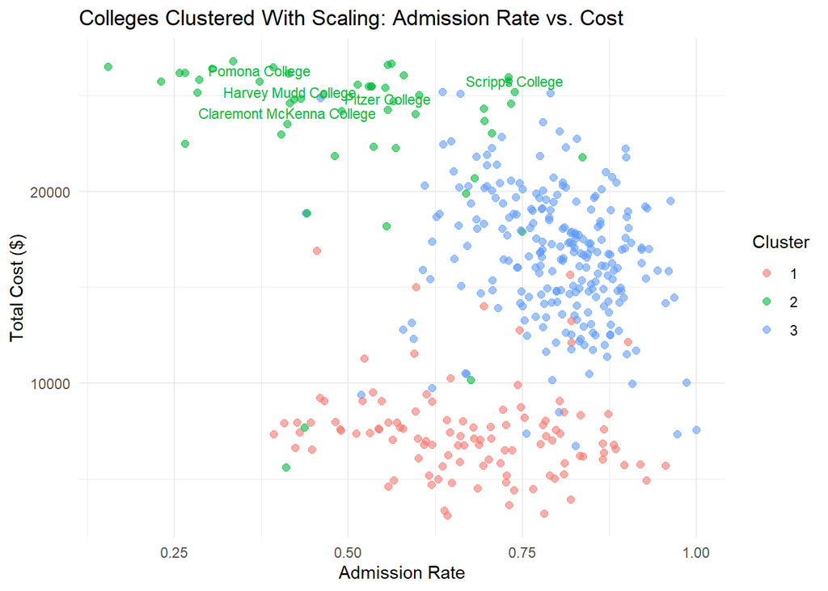

```r
# Your code here
ggplot(college_data, aes(x = adm_rate, y = cost, color = factor(cluster_scaled))) +
  geom_point(alpha = 0.6, size = 2) +
  geom_text(aes(label = claremont_label),
                  size = 3,
                  vjust = -0.5,
                  show.legend = FALSE) +
  labs(title = "Colleges Clustered With Scaling: Admission Rate vs. Cost",
       x = "Admission Rate",
       y = "Total Cost ($)",
       color = "Cluster") +
  theme_minimal()
```

**Your answer:**

Now it makes sense! Even though we scaled all eight variables to have equal influence, the variables measure different dimensions of college characteristics. Selectivity measures (admission rate, SAT scores, HStop10) tend to be correlated with each other, but variables like cost, salary outcomes, enrollment size (FullTime), and donation rates add additional dimensions that cut across selectivity levels.

The clusters we see are grouping schools based on combinations of selectivity, cost, size, outcomes, and institutional characteristics. For example, there might be high-cost selective schools (like elite private colleges including the Claremont Colleges), lower-cost selective schools (like top public universities), large schools versus small schools, and schools with different combinations of these profiles.

**Categorizing the 3 clusters:**

The key observation is that each cluster represents a combination of selectivity, cost, size, and outcomes, not just one dimension.

**Key insight**: Scaling fixes the problem of variables with different numerical scales, but it doesn’t fix the conceptual issue of including variables that measure different dimensions. If we want clusters based purely on selectivity/quality, we might want to use only selectivity-related variables (adm_rate, avg_sat, HStop10) - or we should accept that our clusters will represent multiple institutional characteristics including size, cost, and outcomes.

**Q12: Compare your two clustering results (from Q5 vs. Q10). What changed with scaling, and what problem still remained?**

**Your answer:**

**After scaling (Q10):** All eight variables now had equal mathematical influence, which was better. We could see selectivity-based patterns emerging more clearly. However, because the variables measure different dimensions of college characteristics (selectivity, cost, size, outcomes, student quality), the clusters represent multidimensional profiles rather than pure selectivity groupings.

**The key lesson**: Scaling solves the problem of different numerical ranges, but doesn’t solve the conceptual issue of including variables that measure different dimensions. Even with perfect scaling, including diverse measures (selectivity, cost, size, outcomes) means our clusters represent patterns across multiple institutional characteristics, not just one dimension like selectivity alone.

## Part 4: Choosing the Optimal K (10 minutes)

How do we know if K=3 is the best choice? We’ll use the “elbow method” with our scaled data.

**Q13: Run K-means for K values from 1 to 10 on the SCALED data, storing the total within-cluster sum of squares for each. Create an elbow plot.**

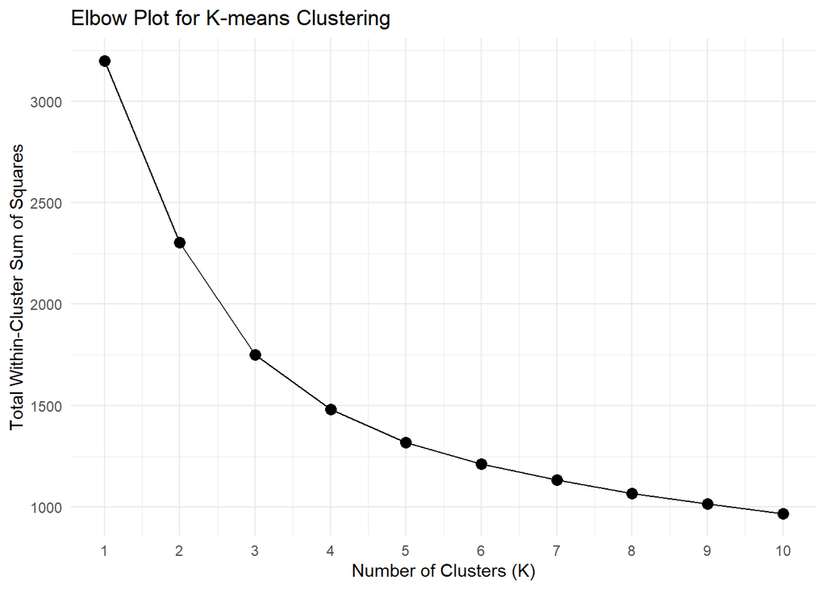

```r
set.seed(122)
# Create a vector of K values to try
k_values <- 1:10

# Your code here: calculate total within SS for each K
total_wss <- sapply(k_values, function(k) {
  # fill in this function - use cluster_vars_scaled
  km_result <- kmeans(cluster_vars_scaled, centers = k, nstart = 20)
  km_result$tot.withinss
})

# Create a data frame for plotting
elbow_data <- data.frame(
  k = k_values,
  total_wss = total_wss
)

# Plot the elbow curve
# Your code here
ggplot(elbow_data, aes(x = k, y = total_wss)) +
  geom_line() +
  geom_point(size = 3) +
  labs(title = "Elbow Plot for K-means Clustering",
       x = "Number of Clusters (K)",
       y = "Total Within-Cluster Sum of Squares") +
  theme_minimal() +
  scale_x_continuous(breaks = 1:10)
```

**Q14: Based on the elbow plot, what value of K would you choose? Why?**

**Your answer:**

Based on the elbow plot, I would choose K = 4.

Looking at the plot, there’s a sharp decrease in total within-cluster sum of squares from K=1 to K=3, then around K=4 we see a clear “elbow” where the rate of decrease becomes more gradual. After K=4, the decreases become more incremental, suggesting diminishing returns.

K=4 provides a good balance between: 1. Having enough clusters to capture meaningful groupings in the data 2. Not having so many clusters that we’re overfitting or creating overly granular groups

The elbow at K=4 suggests this is where we get the most meaningful structure before additional clusters add less and less value. For this analysis, I’ll proceed with K=4.

## Part 5: Interpreting Your Clusters (10 minutes)

Now let’s understand what distinguishes the clusters you found.

**Q15: Re-run K-means with your chosen value of K (from Q14) on the SCALED data, and add these cluster assignments to `college_data` as `cluster_final`.**

```r
set.seed(122)
# Your code here
km_final <- kmeans(cluster_vars_scaled, centers = 4, nstart = 20)

college_data <- college_data %>%
  mutate(cluster_final = km_final$cluster)
```

**Q16: Now that you’ve clustered the colleges, examine which schools ended up in the same cluster as the Claremont Colleges. Find 5-10 schools in this cluster and verify whether they match the types of schools you predicted in Q2.**

```r
# Your code here
# Hint: First, find which cluster contains the Claremont Colleges
# Then, filter for other schools in that same cluster

# Find the cluster number for Claremont Colleges
claremont_cluster <- college_data %>%
  filter(College %in% c("Pomona College", "Claremont McKenna College",
                     "Harvey Mudd College", "Scripps College", "Pitzer College")) %>%
  pull(cluster_final) %>%
  unique()

# Show a sample of schools in the same cluster
college_data %>%
  filter(cluster_final == claremont_cluster) %>%
  select(College, State, adm_rate, avg_sat, HStop10, cost, AvgSalary, FullTime) %>%
  arrange(desc(avg_sat), desc(cost)) %>%
  head(20)
```

```
## # A tibble: 20 × 8
##    College               State adm_rate avg_sat HStop10  cost AvgSalary FullTime
##    <chr>                 <chr>    <dbl>   <dbl>   <dbl> <dbl>     <dbl>    <dbl>
##  1 California Institute… CA       0.265    705       98 22481       866      912
##  2 Massachusetts Instit… MA       0.334    690.      96 26800       757     4481
##  3 Swarthmore College    PA       0.392    651       81 26480       562     1387
##  4 Duke University       NC       0.282    651       90 25165       699     6188
##  5 Columbia University   NY       0.286    650       78 25838       687     3376
##  6 Wesleyan University   CT       0.413    640       60 26130       597     2714
##  7 University of Pennsy… PA       0.422    637       85 24790       744     9205
##  8 Claremont McKenna Co… CA       0.412    635       71 23510       601      887
##  9 College of William a… VA       0.436    620       68  7706       525     5186
## 10 Wellesley College     MA       0.431    615       80 24840       603     2195
## 11 Rose-Hulman Institut… IN       0.554    605       73 18186       549     1320
## 12 Trinity University    TX       0.750    605       62 17890       548     2110
## 13 University of Missou… MO       0.973    601       49  7330       564     3926
## 14 College of the Holy … MA       0.565    600       70 24700       519     2675
## 15 Worcester Polytechni… MA       0.836    600       49 21784       546     2802
## 16 University of Minnes… MN       0.599    600       56  7110       389     1846
## 17 Vanderbilt University TN       0.602    600.      71 25020       612     5500
## 18 Colgate University    NY       0.513    593       46 25575       539     2649
## 19 Colby College         ME       0.463    585       58 25020       524     1720
## 20 Drew University       NJ       0.734    584.      56 24568       529     1192
```

**Your answer:**

## Part 6: Reflection Questions

**Q17: Would you expect clustering results to be identical if you ran the algorithm with a different random seed? Why or why not?**

**Your answer:**

No, the clustering results would likely NOT be identical with a different random seed, but they should be very similar.

Here’s why: - K-means starts by randomly placing K initial cluster centers (centroids) - The algorithm then iteratively assigns points to the nearest centroid and recalculates centroids - Different initial placements (from different random seeds) can lead to different local optima - K-means is guaranteed to converge, but not necessarily to the global optimum

However, we used `nstart=20`, which means the algorithm runs 20 times with different random starting points and returns the best result (lowest total within-cluster sum of squares). This makes the results much more stable across different seeds - while individual runs might vary, the best result among 20 runs is likely to be similar regardless of the overall random seed.

In practice with our data, the main clusters (elite selective schools, moderately selective schools, etc.) should be very similar across different seeds, though individual colleges on the boundaries between clusters might occasionally be assigned differently. The higher the `nstart` value, the more consistent the results will be across different random seeds.

**Q18: Why is it important to standardize variables before performing K-means clustering? What did you observe when comparing your clustering results before and after scaling (Q5 vs. Q10)? Even with scaling, what issue remained (Q11)?**

**Your answer:**

Standardization is crucial for K-means clustering because:

- **After scaling (Q10)**: Scaling gave all eight variables equal mathematical weight. The clusters improved significantly and we could see clearer patterns based on combinations of selectivity, cost, size, and outcomes.
- **The remaining issue (Q11)**: Even with perfect scaling, our variables measure different dimensions - selectivity (adm_rate, avg_sat, HStop10), financial (cost), size (FullTime), outcomes (AvgSalary), and engagement (Donate, Ratio). These dimensions don’t all correlate with each other, so clusters represent multidimensional institutional profiles rather than pure selectivity groupings.

**Key lesson**: Scaling solves the numerical scale problem, but doesn’t solve the conceptual issue of including variables that measure different dimensions of college characteristics. For purely selectivity-based clusters, we should use only selectivity variables, or accept that our clusters represent combinations of multiple institutional characteristics including size, cost, and outcomes.

**Q19: Name one advantage and one disadvantage of K-means clustering compared to supervised learning methods (like decision trees or random forests).**

**Your answer:**

**Advantage of K-means clustering:** K-means doesn’t require labeled training data. In many real-world situations, we don’t have pre-defined categories or outcomes for our data. For example, with our college data, we didn’t need someone to first categorize colleges as “elite,” “good,” or “average” - the algorithm discovered natural groupings in the data on its own. This makes clustering useful for exploratory data analysis, discovering hidden patterns, or when labeling data would be expensive or subjective.

**Disadvantage of K-means clustering:** K-means requires you to specify the number of clusters (K) in advance, and the results can be harder to interpret or validate since there’s no “ground truth” to compare against. With supervised learning, we have actual outcomes to predict and can measure accuracy, but with K-means, determining whether our clusters are “good” or “meaningful” is more subjective. Additionally, K-means assumes spherical clusters and can perform poorly when the natural groups in the data have irregular shapes, whereas some supervised methods (like random forests) can capture more complex patterns.

**Additional consideration:** K-means finds groupings based on similarity, while supervised learning makes predictions. They serve different purposes - clustering for exploration and pattern discovery, supervised learning for prediction and classification.